# VCE Based On Subsampled Data

Peter von Rohr

2019-01-08

## Disclaimer

Different strategies of sub-sampling data from a large data set are evaluated with respect to variance components estimation.

## Introduction

Breeding values are predicted using BLUP animal models (BLUP-AM). BLUP-AM are specialized members of the larger class of linear mixed effect models (LME). In BLUP-AM, predicted breeding values (and estimates for fixed effects) are obtained by solving mixed-model equations which require known variance components from all random components.

## Variance Components Estimation (VCE)

Breeding values are predicted for very large data sets. Normally, these data sets are too large to be used in variance components estimation. Hence we need a method to draw random samples from the data to get estimates of variance components. The goal is to use as small a data sample as possible to still get reliable estimates of variance components.

## Numerical Example

We want to use the data sets in `pedigreemm` to do a few experiments with data sub-sampling. In a first step, we are just reproducing the first example shown in Vazquez et al. (2010). This leads to the following analysis

```r
require(pedigreemm)
milk <- within(milk, sdMilk <- milk / sd(milk))
### # either run the analysis, or load the results from the file
s_result_file <- "fm1.rda"
if (file.exists(s_result_file)){
  load(s_result_file)
} else {
system.time(
  fm1 <- pedigreemm(sdMilk ~ lact + log(dim) + (1|id) + (1|herd),
                    data = milk, pedigree = list(id = pedCowsR)))
  save(fm1, file = s_result_file)
}
```

```r
summary(fm1)
```

```
Linear mixed model fit by REML ['lmerpedigreemm']
Formula: sdMilk ~ lact + log(dim) + (1 | id) + (1 | herd)
   Data: milk

REML criterion at convergence: 8384.8

Scaled residuals:
    Min      1Q  Median      3Q     Max
-4.2902 -0.5251  0.0179  0.5645  3.4840

Random effects:
 Groups   Name        Variance Std.Dev.
 id       (Intercept) 0.2780   0.5273
 herd     (Intercept) 0.2078   0.4559
 Residual             0.4833   0.6952
Number of obs: 3397, groups:  id, 1359; herd, 57

Fixed effects:
            Estimate Std. Error t value
(Intercept)  1.70371    0.26854   6.344
lact        -0.10779    0.01232  -8.747
log(dim)     0.73594    0.04380  16.804

Correlation of Fixed Effects:
         (Intr) lact
lact     -0.296
log(dim) -0.960  0.221
```

## Subsampling

In our example the complete data set contains 3397 records. From the complete record, we want to take a random sample of a given size and from this smaller data set variance components should be estimated again.

## Strategies

Several strategies are possible to generate smaller data sets from the complete data set. The following list presents some of them

- Randomly select records from the large data set
- Keep the records coming from the largest herds

### Random Selection

The strategy of `random selection` mean that we are just randomly choosing observations out of the complete data set. This is done via the function `sample()` which draws a random sample out of a large data set.

```r
set.seed(432)
n_sample_size <- 500
vec_rsample_idx <- sample(1:nrow(milk), size = n_sample_size)
df_rsample_milk <- milk[vec_rsample_idx,]
dim(df_rsample_milk)
```

```
[1] 500  10
```

```r
head(df_rsample_milk)
```

|  | id | lact | herd | sire | dim | milk | fat | prot | scs | sdMilk |
| --- | --- | --- | --- | --- | --- | --- | --- | --- | --- | --- |
| 941 | 5137 | 1 | 45 | 324 | 612 | 26126 | 1251 | 877 | 1.79 | 5.841836 |
| 140 | 4928 | 3 | 75 | 3 | 999 | 26855 | 901 | 847 | 1.98 | 6.004842 |
| 3446 | 5720 | 3 | 14 | 349 | 334 | 23785 | 980 | 770 | 2.49 | 5.318383 |
| 630 | 6430 | 1 | 77 | 321 | 403 | 22159 | 858 | 661 | 1.96 | 4.954805 |
| 2711 | 4973 | 5 | 69 | 346 | 134 | 27713 | 905 | 832 | 2.63 | 6.196693 |
| 3501 | 6091 | 2 | 26 | 350 | 276 | 17816 | 688 | 554 | 3.87 | 3.983700 |

Now the same analysis is done using the smaller sample data set.

```r
s_result_file_rsample <- "fm1rsample.rda"
if (file.exists(s_result_file_rsample)){
  load(s_result_file_rsample)
} else {
system.time(
  fm1rsample <- pedigreemm(sdMilk ~ lact + log(dim) + (1|id) + (1|herd),
                    data = df_rsample_milk, pedigree = list(id = pedCowsR)))
  save(fm1rsample, file = s_result_file_rsample)
}
```

The results are

```r
summary(fm1rsample)
```

```
Linear mixed model fit by REML ['lmerpedigreemm']
Formula: sdMilk ~ lact + log(dim) + (1 | id) + (1 | herd)
   Data: df_rsample_milk

REML criterion at convergence: 1294.6

Scaled residuals:
     Min       1Q   Median       3Q      Max
-2.78451 -0.46312 -0.06044  0.47636  2.29673

Random effects:
 Groups   Name        Variance Std.Dev.
 id       (Intercept) 0.3552   0.5960
 herd     (Intercept) 0.1625   0.4031
 Residual             0.3857   0.6210
Number of obs: 500, groups:  id, 427; herd, 44

Fixed effects:
            Estimate Std. Error t value
(Intercept)  2.42635    0.70713   3.431
lact        -0.12335    0.03368  -3.662
log(dim)     0.62128    0.11874   5.232

Correlation of Fixed Effects:
         (Intr) lact
lact     -0.252
log(dim) -0.989  0.161
```

The same subsampling of the data should be repeated and we want to collect the variance estimates. First, we have to check how to extract the variance estimates from `fm1rsample`. The function `VarCorr()` can be used to extract the variance components. The result object of `VarCorr()` has a print method with an argument `comp` which can be used to indicate which components should be printed

```r
o_cur_rsample <- VarCorr(fm1rsample)
print(o_cur_rsample, comp=c("Variance","Std.Dev."))
```

```
 Groups   Name        Variance Std.Dev.
 id       (Intercept) 0.35516  0.59595
 herd     (Intercept) 0.16251  0.40312
 Residual             0.38568  0.62103
```

The single components are obtained by

```r
o_cur_rsample$id[1,1]
```

```
[1] 0.3551609
```

for the genetic additive variance, by

```r
o_cur_rsample$herd[1,1]
```

```
[1] 0.162509
```

for the herd variance and by

```r
attr(o_cur_rsample, "sc")
```

```
[1] 0.6210321
```

for the residual standard deviation.

### Additional Aspects of lmer Results

The variance-covariance matrix of the estimates of the fixed effects are obtained by

```r
vcov(fm1rsample)
```

```
3 x 3 Matrix of class "dpoMatrix"
             (Intercept)         lact     log(dim)
(Intercept)  0.500029606 -0.006010717 -0.083022624
lact        -0.006010717  0.001134506  0.000642813
log(dim)    -0.083022624  0.000642813  0.014099638
```

The variance of the residuals is

```r
var(resid(fm1rsample))
```

```
[1] 0.2132084
```

The deviance is obtained from the slot `devcomp`

```r
fm1rsample@devcomp
```

```
$cmp
        ldL2        ldRX2         wrss         ussq        pwrss        drsum         REML          dev      sigmaML    sigmaREML
 344.4353391   13.2186788  106.3910077   85.2923990  191.6834067           NA 1294.5646855           NA    0.6191662    0.6210321

$dims
     N      n      p    nmp      q    nth  useSc reTrms   spFe   REML   GLMM   NLMM
   500    500      3    497    471      2      1      2      0      3      0      0
```

### Bootstrap Repetitions

Now we are ready to repeat the sub-sampling a number of times and get boot-strapped results.

```r
n_nr_rep <- 3
l_rep_results <- sapply(1:n_nr_rep,
                        function(x, pn_sample_size){
                          vec_rsample_idx <- sample(1:nrow(milk), size = n_sample_size)
                          df_rsample_milk <- milk[vec_rsample_idx,]
                          fm1rsample <- pedigreemm(sdMilk ~ lact + log(dim) + (1|id) + (1|herd),
                                                   data = df_rsample_milk, pedigree = list(id = pedCowsR))
                          o_cur_rsample_result <- VarCorr(fm1rsample)
                          return(list(id = o_cur_rsample_result$id[1,1],
                                      herd = o_cur_rsample_result$herd[1,1],
                                      residual = attr(o_cur_rsample_result, "sc")^2))
                        }, n_sample_size)
```

From these results, we take the mean and the standard deviation

| Component | Sub Sample Mean | Sub Sample Sd |
| --- | --- | --- |
| Id | 0.0996241 | 0.0228007 |
| Herd | 0.2222010 | 0.0572718 |
| Residual | 0.6115095 | 0.0260834 |

### Largest Herds

Whether the sub-sampling based on herd size is a good strategy or not could depend on the distribution of herd sizes. The following frequency table and the following histogram gives a first impression on the distribution

```r
table(milk$herd)
```

```
  1   2   4   5   6   7   8  13  14  17  18  22  23  26  27  29  30  34  36  37  38  41  45  46  48  49  52  53  54  55  59  60  62  64  66  68  69  70  75  77  89  90  95  96  97  98  99 100 101 103 104 105 106 107 108 109 110
 68 231  76  62  64  28  82  56 255  45  66  56 159   9  11  49  57  87  43  69  98  72 122  57  53  18  91  37  41  34 178 115  28 104  53 113 137 104 115  16 123  66   2   2   1   7   2   2   2   2   3   1   2   1   1  19   2
```

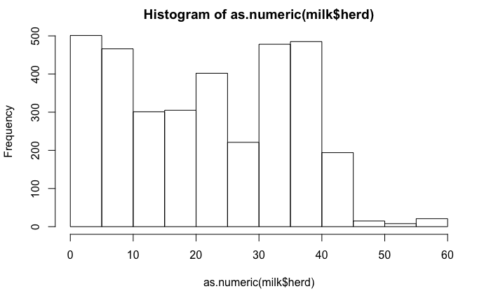

```r
hist(as.numeric(milk$herd))
```

Drawing the histogram using `ggplot2` leads to

```
Ignoring unknown parameters: binwidth, bins, pad
```

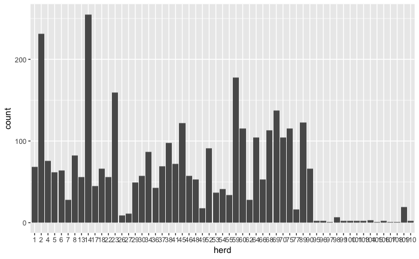

```r
require(ggplot2)
ggplot(milk, aes(herd)) + geom_histogram(stat = "count")
```

When data are to be sampled based on herd size, we have to sort the original data set according to herdsize.

```r
require(dplyr)
tbl_milk <- tibble::as_tibble(milk)
tbl_milk_hs <- tbl_milk %>%
  group_by(herd) %>%
  summarize(herdsize = n()) %>%
  arrange(desc(herdsize)) %>%
  mutate(cumhs = cumsum(herdsize))
tbl_milk_hs
```

| herd | herdsize | cumhs |
| --- | --- | --- |
| 14 | 255 | 255 |
| 2 | 231 | 486 |
| 59 | 178 | 664 |
| 23 | 159 | 823 |
| 69 | 137 | 960 |
| 89 | 123 | 1083 |
| 45 | 122 | 1205 |
| 60 | 115 | 1320 |
| 75 | 115 | 1435 |
| 68 | 113 | 1548 |

[output cut: 47 more lines]

To get a certain sample size, a filter on the cumulative herd size is applied.

```r
tbl_hs_herd <- tbl_milk_hs %>% filter(cumhs < n_sample_size)
tbl_hs_herd
```

| herd | herdsize | cumhs |
| --- | --- | --- |
| 14 | 255 | 255 |
| 2 | 231 | 486 |

Because, we want to have a dataset with at least 500 of observations, we include an additional row from the sorted `tbl_df`.

```r
n_last_row_chosen <- nrow(tbl_hs_herd)
tbl_hs_herd <- tbl_hs_herd %>% bind_rows(tbl_milk_hs[(n_last_row_chosen+1),])
tbl_hs_herd
```

| herd | herdsize | cumhs |
| --- | --- | --- |
| 14 | 255 | 255 |
| 2 | 231 | 486 |
| 59 | 178 | 664 |

The tibble `tbl_hs_herd` is used to select observations from the original dataset by joining `tbl_hs_herd` back to the original `tbl_milk` using the column `herd` as joining criterion.

```r
tbl_milk_hs_sample <- tbl_milk %>% inner_join(tbl_hs_herd)
tbl_milk_hs_sample
```

| id | lact | herd | sire | dim | milk | fat | prot | scs | sdMilk | herdsize | cumhs |
| --- | --- | --- | --- | --- | --- | --- | --- | --- | --- | --- | --- |
| 5147 | 1 | 2 | 3 | 306 | 23265 | 927 | 708 | 2.26 | 5.202109 | 231 | 486 |
| 5147 | 2 | 2 | 3 | 345 | 17571 | 709 | 601 | 5.45 | 3.928917 | 231 | 486 |
| 5147 | 3 | 2 | 3 | 475 | 16674 | 715 | 590 | 6.90 | 3.728346 | 231 | 486 |
| 5148 | 1 | 2 | 3 | 292 | 27443 | 958 | 746 | 2.03 | 6.136320 | 231 | 486 |
| 5148 | 2 | 2 | 3 | 214 | 18775 | 702 | 568 | 2.06 | 4.198135 | 231 | 486 |
| 5151 | 1 | 2 | 3 | 721 | 22839 | 925 | 682 | 2.63 | 5.106855 | 231 | 486 |
| 5159 | 1 | 2 | 3 | 308 | 28621 | 1094 | 850 | 2.01 | 6.399724 | 231 | 486 |
| 5159 | 2 | 2 | 3 | 350 | 26158 | 973 | 783 | 2.36 | 5.848991 | 231 | 486 |
| 5159 | 3 | 2 | 3 | 392 | 16608 | 772 | 540 | 4.46 | 3.713588 | 231 | 486 |
| 5159 | 4 | 2 | 3 | 295 | 22652 | 887 | 757 | 5.59 | 5.065041 | 231 | 486 |

[output cut: 654 more lines]

This sample tibble has dimensions

```r
dim(tbl_milk_hs_sample)
```

```
[1] 664  12
```

Now the analysis is done based on this sample tibble dataframe

```r
s_hs_sample <- "fm1hssample.rda"
if (file.exists(s_hs_sample)){
  load(s_hs_sample)
} else {
  fm1hssample <- pedigreemm(sdMilk ~ lact + log(dim) + (1|id) + (1|herd),
                    data = tbl_milk_hs_sample, pedigree = list(id = pedCowsR))
  save(fm1hssample, file = s_hs_sample)

}
summary(fm1hssample)
```

```
Linear mixed model fit by REML ['lmerpedigreemm']
Formula: sdMilk ~ lact + log(dim) + (1 | id) + (1 | herd)
   Data: tbl_milk_hs_sample

REML criterion at convergence: 1624.5

Scaled residuals:
    Min      1Q  Median      3Q     Max
-4.3134 -0.4867  0.0175  0.5806  2.9230

Random effects:
 Groups   Name        Variance Std.Dev.
 id       (Intercept) 0.21575  0.4645
 herd     (Intercept) 0.01912  0.1383
 Residual             0.51220  0.7157
Number of obs: 664, groups:  id, 247; herd, 3

Fixed effects:
            Estimate Std. Error t value
(Intercept)  0.53364    0.62062   0.860
lact        -0.12227    0.02748  -4.449
log(dim)     0.92555    0.10285   8.999

Correlation of Fixed Effects:
         (Intr) lact
lact     -0.339
log(dim) -0.985  0.260
```

These results show a clearly reduced herd-variance component and an increased value of the residual variance component compared to the estimate of the complete dataset. The estimate of the genetic-additive variance is comparable to what was obtained with the complete dataset. Selecting a subset of the data just on the criterion of large herd sizes does not give us the opportunity to repeat the vce based on different subset selections as was the case in the random selection strategy. This can be compensated by setting a minimum number of observation per herd and then randomly select from this smaller dataset.

## Connectedness

[output not shown]